# Spatial Classes

### Spatial Objects

In sp, spatial classes are hierarchical in nature. The more specific classes extend those that precede them. In this script we will consider only vector data classes (points, lines, and polygons) because it is not clear that raster data is yet needed for my research.

The foundation class is called 'Spatial'. First we must enable R usage within the IPython environment...

```python
import numpy as np
import pandas as pd
from pandas import Series, DataFrame

#Set print width
pd.set_option('line_width',140)

#Enable R capability
%load_ext rmagic

#Set working directory (cloned from Github)
workdir='/home/choct155/analysis/asdar/asdar/'
```

And now we can use R on a cell by cell basis...

```python
%%R
library(sp)

#Set working directory (cloned from Github)
workdir<-'/home/choct155/analysis/asdar/asdar/'

#Examine Spatial class
print(getClass("Spatial"))
```

```
Class "Spatial" [package "sp"]

Slots:

Name:         bbox proj4string
Class:      matrix         CRS

Known Subclasses:
Class "SpatialPoints", directly
Class "SpatialGrid", directly
Class "SpatialLines", directly
Class "SpatialPolygons", directly
Class "SpatialPointsDataFrame", by class "SpatialPoints", distance 2
Class "SpatialPixels", by class "SpatialPoints", distance 2
Class "SpatialGridDataFrame", by class "SpatialGrid", distance 2
Class "SpatialLinesDataFrame", by class "SpatialLines", distance 2
Class "SpatialPixelsDataFrame", by class "SpatialPoints", distance 3
Class "SpatialPolygonsDataFrame", by class "SpatialPolygons", distance 2
```

The basic Spatial class carries only two slots (or class attributes). The first slot is bbox, which is short for bounding box. It is a matrix object that has two columns (['min','max']) and at least two rows (['x-axis','y-axis']).

```python
from pandas import DataFrame
import numpy as np

#Imaginary value creation
a=np.empty((2,2,))
a[:]=np.NAN

#Bounding Box example creation
bbox=DataFrame(a,index=['x_axis','y_axis'], columns=['min','max'])
bbox
```

|  | min | max |
| --- | --- | --- |
| x_axis | NaN | NaN |
| y_axis | NaN | NaN |

The bounding box provides the dimensions of the spatial plotting area. The second slot, proj4string, refers to the coordinate reference system. bbox is itself of class matrix, a primary data structure. proj4string of class CRS, on the other hand, can be explored further...

```python
%%R
print(getClass("CRS"))
```

```
Class "CRS" [package "sp"]

Slots:

Name:   projargs
Class: character
```

The CRS slot takes a string as its input (hence the character class). This string identifies the projection to be used in mapping features. The input string should in PROJ.4-format. In the simplest case for geographical coordinates, the input string would be "+proj=longlat". Eastings (longitude) always come before northings (latitude) in sp classes.

Equipped with this knowledge, we can build a basic Spatial object. This need not be done solely in the R environment since we can pass objects between the IPython and R namespaces. Nevertheless...

```python
%%R
print('***Define Bounding Box***')
#Create matrix for bbox
m<-matrix(c(0,0,1,1),
          ncol=2,
          dimnames=list(NULL,c('min','max')))
#The null value occupies the space for row values, so min and max can describe columns
print(m)

cat('\n')
print('***Define CRS Class***')
#Define CRS class instance with prescribed input
crs<-CRS(projargs=as.character(NA))
print(crs)

cat('\n')
print('***Define Alternate CRS Class***')
#If we wanted to use our projection from above
crs2<-CRS(projargs='+proj=longlat')
print(crs2)

cat('\n')
print('***Capture Slot Definitions in New Spatial Object***')
S<-Spatial(bbox=m,proj4string=crs)
print(S)
```

```
[1] "***Define Bounding Box***"
     min max
[1,]   0   1
[2,]   0   1

[1] "***Define CRS Class***"
CRS arguments: NA

[1] "***Define Alternate CRS Class***"
CRS arguments: +proj=longlat

[1] "***Capture Slot Definitions in New Spatial Object***"
An object of class "Spatial"
Slot "bbox":
     min max
[1,]   0   1
[2,]   0   1

Slot "proj4string":
CRS arguments: NA
```

### SpatialPoints

As a consequence of the elliptical nature of the earth, coordinates alone cannot define a location on a sphere exactly. We must also know which elliptoid model has been used to model the earth (they are not all the same). Even if we did have a perfect sphere, longitudinal position could not be known without establishing a prime meridian. Thus, point location requires all three of these elements.

To play around with this, we will use the CRAN mirrors data housed on Github...

```python
%%R -w 850 -h 480

#Set print width
options(width = 160)

#Read data
CRAN_df<-read.table(paste(workdir,'CRAN051001a.txt',sep=""),header=TRUE)
print(CRAN_df)
```

```
             place   north     east                    loc         long       lat
1         Brisbane 27d28'S 153d02'E              Australia  153.0333333 -27.46667
2        Melbourne 37d49'S 144d58'E              Australia  144.9666667 -37.81667
3             Wien 48d13'N  16d20'E                Austria   16.3333333  48.21667
4         Curitiba 25d25'S  49d16'W                 Brazil  -49.2666667 -25.41667
5        Vi\xe7oza 20d45'S  42d52'W                 Brazil  -42.8666667 -20.75000
6   Rio de Janeiro 22d54'S  43d12'W                 Brazil  -43.2000000 -22.90000
7       Piracicaba 22d43'S  47d38'W                 Brazil  -47.6333333 -22.71667
8     Sa\xf5 Paulo 23d32'S  46d38'W                 Brazil  -46.6333333 -23.53333
9          Burnaby 49d15'N 122d57'W British Columbia (CAN) -122.9500000  49.25000
10         Toronto 43d39'N  79d23'W          Ontario (CAN)  -79.3833333  43.65000
11         Nanjing 32d03'N 118d47'E                  China  118.7833333  32.05000
12         Aalborg 57d03'N   9d56'E                Denmark    9.9333333  57.05000
13        Toulouse 43d36'N   1d26'E                 France    1.4333333  43.60000
14            Lyon 45d45'N   4d51'E                 France    4.8500000  45.75000
```

[output cut: 40 more lines]

We can construct the coordinate matrix from the lat and long variables.

```python
%%R
#Subset to long and lat colums
CRAN_mat<-cbind(CRAN_df$long,CRAN_df$lat)

#Create index for row names
row.names(CRAN_df)<-1:nrow(CRAN_mat)

#Examine structure of new coord matrix
str(CRAN_mat)
```

```
 num [1:54, 1:2] 153 145 16.3 -49.3 -42.9 ...
```

We will also need, as may be guessed, a projection. Note that we are also specifying an elliptoid model.

```python
%%R
#Establish coordinate reference system
llCRS<-CRS('+proj=longlat +ellps=WGS84')
```

Now with the appropriate components, let's look at the requirements for SpatialPoints...

```python
%%R
print(getClass('SpatialPoints'))
```

```
Class "SpatialPoints" [package "sp"]

Slots:

Name:       coords        bbox proj4string
Class:      matrix      matrix         CRS

Extends: "Spatial"

Known Subclasses:
Class "SpatialPointsDataFrame", directly
Class "SpatialPixels", directly
Class "SpatialPixelsDataFrame", by class "SpatialPixels", distance 2
```

We can see that there are now three slots. **bbox** and **proj4string** remain from the foundational Spatial object. SpatialPoints, however, also includes a **coords** slot. Applying the above coordinates and projection to a new SpatialPoints object gives us something to explore.

```python
%%R
#Create new Points object
CRAN_sp<-SpatialPoints(CRAN_mat,proj4string=llCRS)

#Examine object
print(summary(CRAN_sp))
```

```
Object of class SpatialPoints
Coordinates:
                 min      max
coords.x1 -122.95000 153.0333
coords.x2  -37.81667  57.0500
Is projected: FALSE
proj4string : [+proj=longlat +ellps=WGS84]
Number of points: 54
```

Note that we did not have to explicitly enter a **bbox** argument. The object determined its own plot boundaries from the coordinate matrix. The summary also tells us whether it is projected (it is not because we are using 'longlat'), the argument provided in the **proj4string** slot, and the number of points. Note that there is no SpatialPoint class, SpatialPoints can handle one point at a time.

If we want to examine the slots of an object one at a time, we can call the slot names as methods. (Note **coords** is called by *coordinates*.) This also works on subsets, and we can also use methods to change the value of slots...

```python
%%R
#Examine bbox
print(bbox(CRAN_sp))
cat('\n')

#Examine coordinate
print(coordinates(CRAN_sp))
cat('\n')

#Alter coordinate reference system
proj4string(CRAN_sp)<-CRS(as.character(NA))
print('The new, but temporary, CRS is:')
print(proj4string(CRAN_sp))
cat('\n')

#Fix coordinate reference system
proj4string(CRAN_sp)<-llCRS
```

```
                 min      max
coords.x1 -122.95000 153.0333
coords.x2  -37.81667  57.0500

         coords.x1 coords.x2
 [1,]  153.0333333 -27.46667
 [2,]  144.9666667 -37.81667
 [3,]   16.3333333  48.21667
 [4,]  -49.2666667 -25.41667
 [5,]  -42.8666667 -20.75000
 [6,]  -43.2000000 -22.90000
 [7,]  -47.6333333 -22.71667
 [8,]  -46.6333333 -23.53333
 [9,] -122.9500000  49.25000
[10,]  -79.3833333  43.65000
```

[output cut: 47 more lines]

If we want to work with the data more easily, or integrate information from different sources, we need to get to a general data.frame format. The class that captures this behavior is the remarkably original SpatialPointsDataFrame. To build an SPDF, we need to ensure that the rows coordinate matrix are appropriately coupled with the rows of the data.frame. One way to get there is to make sure that the *match.ID* argument is toggled to TRUE, and the row names in the matrix correspond to row names in the data.frame.

```python
%%R
#Peek at components to be combined
print(head(CRAN_mat))
print(head(CRAN_df))

#Construct SpatialPointsDataFrame
CRAN_spdf1<-SpatialPointsDataFrame(CRAN_mat,CRAN_df,proj4string=llCRS,match.ID=TRUE)
print(CRAN_spdf1)
```

```
          [,1]      [,2]
[1,] 153.03333 -27.46667
[2,] 144.96667 -37.81667
[3,]  16.33333  48.21667
[4,] -49.26667 -25.41667
[5,] -42.86667 -20.75000
[6,] -43.20000 -22.90000
           place   north     east       loc      long       lat
1       Brisbane 27d28'S 153d02'E Australia 153.03333 -27.46667
2      Melbourne 37d49'S 144d58'E Australia 144.96667 -37.81667
3           Wien 48d13'N  16d20'E   Austria  16.33333  48.21667
4       Curitiba 25d25'S  49d16'W    Brazil -49.26667 -25.41667
5      Vi\xe7oza 20d45'S  42d52'W    Brazil -42.86667 -20.75000
6 Rio de Janeiro 22d54'S  43d12'W    Brazil -43.20000 -22.90000
            coordinates           place   north     east                    loc         long       lat
```

[output cut: 54 more lines]

We can also pass a SpatialPoints object as the first argument, or assign directly to a data.frame, to get there.

```python
%%R
#Generate equivalent SPDFs
CRAN_spdf2<-SpatialPointsDataFrame(CRAN_sp,CRAN_df)

CRAN_df0<-CRAN_df
coordinates(CRAN_df0)<-CRAN_mat
proj4string(CRAN_df0)<-llCRS

#Check equivalency
print(all.equal(CRAN_spdf1,CRAN_spdf2))
print(all.equal(CRAN_spdf1,CRAN_df0))
```

```
[1] TRUE
[1] TRUE
```

Just for consistency...

```python
%%R
print(getClass("SpatialPointsDataFrame"))
```

```
Class "SpatialPointsDataFrame" [package "sp"]

Slots:

Name:         data  coords.nrs      coords        bbox proj4string
Class:  data.frame     numeric      matrix      matrix         CRS

Extends:
Class "SpatialPoints", directly
Class "Spatial", by class "SpatialPoints", distance 2

Known Subclasses:
Class "SpatialPixelsDataFrame", directly, with explicit coerce
```

### SpatialLines

Construction of lines in sp is a multi-stage process. The basic object, **line**, is represented as a series of coordinates.

```python
%%R
print(getClass("Line"))
```

```
Class "Line" [package "sp"]

Slots:

Name:  coords
Class: matrix

Known Subclasses: "Polygon"
```

These lines are then aggregated into lists of line objects called **Lines**.

```python
%%R
print(getClass("Lines"))
```

```
Class "Lines" [package "sp"]

Slots:

Name:      Lines        ID
Class:      list character
```

And it is this list of **Line** objects, or single **Lines** object, that fits into the **lines** slot in a SpatialLines object.

```python
%%R
print(getClass("SpatialLines"))
```

```
Class "SpatialLines" [package "sp"]

Slots:

Name:        lines        bbox proj4string
Class:        list      matrix         CRS

Extends: "Spatial"

Known Subclasses: "SpatialLinesDataFrame"
```

Note that neither **Line** nor **Lines** objects inherit from Spatial objects. They are solely inputs into SpatialLines objects, which *do*, in fact, inherit both **bbox** and **proj4string** slots from Spatial objects.

We can examine this object in action by leveraging the map2SpatialLines function in the maptools library.

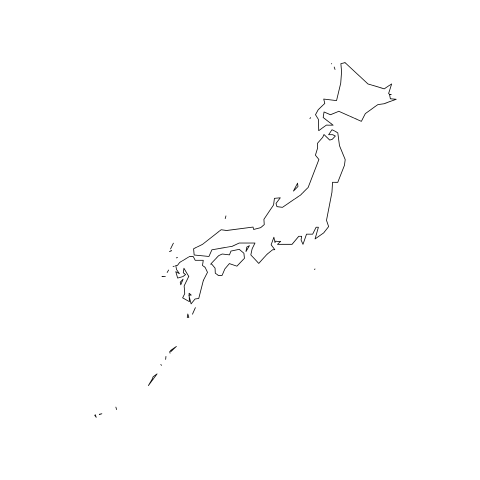

```python
%%R
library(maps)
library(maptools)

japan<-map('world','japan')
```

We are literally going to grab the boundaries as Lines objects and park them in a SpatialLines objects.

```python
%%R
#Set coordinate reference system
p4s<-CRS('+proj=longlat +ellps=WGS84')

#Migrate map boundaries into SpatialLines object
SLjapan<-map2SpatialLines(japan,proj4string=p4s)

#Examine contents of new object (lengthy output, but it grabbed 51 lines)
#print(str(SLjapan))
```

```python
%%R
#Extract lengths of each Lines object in the lines slot
Lines_len<-sapply(slot(SLjapan,"lines"),
                  function(x) length(slot(x,"Lines")))

#Output to a table
print(table(Lines_len))
```

```
Lines_len
 1
51
```

This tells us that each of the 51 **Lines** objects contains one **Line** object. In any event, we can also read Mapgen format into SpatialLines objects.

### SpatialPolgons

SpatialPolygon objects are much like lines with respect to construction. The base object is of class **Polygon**.

```python
%%R
print(getClass("Polygon"))
```

```
Class "Polygon" [package "sp"]

Slots:

Name:    labpt    area    hole ringDir  coords
Class: numeric numeric logical integer  matrix

Extends: "Line"
```

The **Polygon** class actually extends the **Line** class, as evidence by its possession of a **coords** slot that takes matrix inputs. The difference is the addition of four more classes: >1. **labpt** - label point, taken as the centroid of the polygon

> 2. **area** - the are of the polygon measured in the same metric as the coordinates
> 3. **hole** - declaration of the presence of holes (defaults to NA)
> 4. **ringDir** - a path related characteristic indicating the order in which coordinate points should be connected

It should be noted that there is no check for crossing lines or other polygon errors.

The **Polygons** class contains a list of valid **Polygon** objects.

```python
%%R
print(getClass("Polygons"))
```

```
Class "Polygons" [package "sp"]

Slots:

Name:   Polygons plotOrder     labpt        ID      area
Class:      list   integer   numeric character   numeric
```

Just as **Lines** is a list container for **Line** objects, **Polygons** is a list container for **Polygon** objects. **Polygons** also contain the following slots: >1. **ID** - just as with **Lines**, this is a vector of strings identifying individual **Polygon** objects

> 2. **labpt** - in this case identifies the label point of constituent **Polygon** with the largest area
> 3. **plotOrder** - a helper slot to facilitate plotting with R graphics
> 4. **area** - the cumulative sum of all **Polygon** areas

The **SpatialPolygon** class couples a list of **Polygons** objects with the basic **Spatial** object slots of **bbox** and **proj4string** (and a helper slot for plotting order).

```python
%%R
print(getClass("SpatialPolygons"))
```

```
Class "SpatialPolygons" [package "sp"]

Slots:

Name:     polygons   plotOrder        bbox proj4string
Class:        list     integer      matrix         CRS

Extends: "Spatial"

Known Subclasses: "SpatialPolygonsDataFrame"
```

As with **SpatialLines**, **SpatialPolygons** are typically imported rather than built from scratch. Another similarity is a data.frame construct, **SpatialPolygonsDataFrame**. Again, the identifying tags of the **Polygons** objects must correspond with the row names of the data.frame to build a valid SPDF object.

To explore these, we can again cannabalize an existing map to gather our desired objects.

```
[1] 63
```

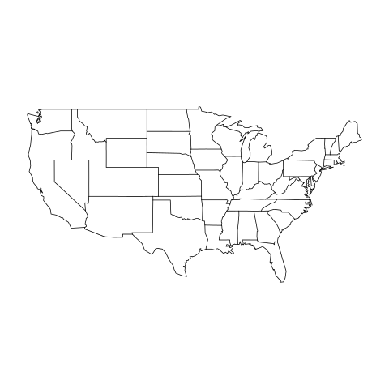

```python
%%R
state.map.plot<-map('state')
state.map<-map("state",plot=FALSE,fill=TRUE)
print(length(state.map$names))
```

*Note that setting the fill argument to true not only colors in the polygons, but also changes the length of the constructed object.*

```python
%%R
#Extract only state names
IDs<-sapply(strsplit(state.map$names,':'),function(x) x[1])

#Capture polygons from the map, applying the newly stripped down IDs
state.sp<-map2SpatialPolygons(state.map,
                              IDs=IDs,
                              proj4string=CRS('+proj=longlat +ellps=WGS84'))
```

With **SpatialPolygons** object in hand, we can pull in the data and build and SPDF.

```python
%%R
#Read in data
sat<-read.table(paste(workdir,'state.sat.data_mod.txt',sep=""),
                row.names=5,
                header=TRUE)

#Sync row names of data (sat) with the IDs of the polygons in the *polygons* slot of SpatialPolygons object
id<-match(row.names(sat),
          sapply(slot(state.sp,'polygons'),
          function(x) slot(x,'ID')))

#Those that could not be matched to polygons have been converted to NA
print(row.names(sat)[is.na(id)])

#Subset to only those rows that are non-null after the matching process
sat_sub<-sat[row.names(sat)[!is.na(id)],]

#Generate SPDF
state.spdf<-SpatialPolygonsDataFrame(state.sp,sat_sub)
print(summary(state.spdf))
```

```
[1] "alaska" "hawaii" "usa"
Object of class SpatialPolygonsDataFrame
Coordinates:
         min       max
x -124.68134 -67.00742
y   25.12993  49.38323
Is projected: FALSE
proj4string : [+proj=longlat +ellps=WGS84]
Data attributes:
     oname        vscore          mscore            pc
 ala    : 1   Min.   :479.0   Min.   :475.0   Min.   : 4.00
 ariz   : 1   1st Qu.:504.0   1st Qu.:503.0   1st Qu.: 9.00
 ark    : 1   Median :527.0   Median :526.0   Median :32.00
 calif  : 1   Mean   :533.8   Mean   :533.7   Mean   :36.43
 colo   : 1   3rd Qu.:563.0   3rd Qu.:558.0   3rd Qu.:65.00
 conn   : 1   Max.   :594.0   Max.   :605.0   Max.   :80.00
 (Other):43
```